# Model-specific focal points in one-shot visual coordination

Steps 1 and 1b — GPT-5.4 and Claude Opus 4.8

LLM Coordination project · report generated 2026-08-06 · all figures and statistics computed from the run CSVs at build time

## Summary

- **Both models coordinate on visual form, and they do it differently.** Across a five-pair battery and a 30-pair screen, dyadic match probability ranges from chance to 1.000 depending on the stimulus, and the two models dissociate on 8 of 30 screened pairs.
- **Crossovers exist in both directions.** 5 pairs where GPT is more concentrated, 3 where Claude is. The strongest single result is `s_arrow` (Claude 1.000 vs GPT 0.503).
- **A model that cannot find a form rule does not answer randomly — it defaults to a side, and then justifies that choice in form language.** This is the central methodological finding and it invalidates any analysis that reads a 50/50 identity split as “no preference” without checking position.
- **Competing-cue stimuli did not produce dissociations.** 18 of 30 pairs sat at a perfect 1.000/1.000 ceiling, including 9 of the 14 pairs built specifically to put two cues in conflict. Both models resolve cue conflicts the same way.

## 1. Task and procedure

Each trial is an independent, one-shot API call with no conversation history. The model sees a single composite image containing two shapes side by side and must pick the one it believes another instance of itself would also pick. There is no communication and no feedback.

### Prompt

Hash `3003ae1b`, stamped on every row of every run reported here. Byte-identical to the arm-1 prompt of the project’s earlier `confidence_calibration_probe.py`, so this data is comparable with that series.

### Counterbalancing and recoding

Each pair exists in two layouts: `AB` places identity 1 on the left, `BA` places identity 2 there. Allocation is exactly half and half in every cell. The model answers with a *position* (`CHOICE: LEFT` / `RIGHT`), which is recoded offline to a stimulus identity via the layout. Because the counterbalance is exactly balanced, a pure position strategy yields a 50/50 identity split — it reads as chance rather than as a spurious preference.

### Models and settings

|  | GPT | Claude |
| --- | --- | --- |
| model id | `gpt-5.4` | `claude-opus-4-8` |
| endpoint | Responses API | Messages API |
| reasoning / thinking | effort low, summary auto | adaptive, summarized |
| max tokens | not set | 2000 |
| temperature / top_p / top_k | not set | not set |
| seed | not exposed by the API | not exposed by the API |

Settings were fixed across every call; each model shows exactly one distinct settings string in the data. The only seeded component is the counterbalance RNG (`20260804`), which is deterministic.

## 2. Measures

**Unbiased dyadic match probability.** With counts *n<sub>k</sub>* over identities and *N* trials, Σ<sub>k</sub> *n<sub>k</sub>*(*n<sub>k</sub>*−1) / *N*(*N*−1). This is the probability that two *distinct* trials agree — the right quantity for “would two independent instances pick the same shape”. The plug-in Σ*p<sub>k</sub>*<sup>2</sup> is reported alongside as a check and runs slightly higher. Chance is 0.5. Confidence intervals are percentile 95% from 5,000 bootstrap resamples at a fixed per-cell seed.

**Conditional-position diagnostic.** For a model’s modal identity *m*, compute the rate at which *m* is chosen separately under each layout: *p*(*m* | *m* on the left) and *p*(*m* | *m* on the right). A model choosing by **form** picks *m* at the same rate either way. A model choosing by **side** picks *m* only when it happens to sit on the favoured side, driving the two rates to 1 and 0. Reported as *form consistency* = 1 − |*p*<sub>AB</sub> − *p*<sub>BA</sub>|.

**This diagnostic is necessary but not sufficient.** A model answering at random also scores near 1 on form consistency, so it is only meaningful read jointly with a match rate above chance. Both conditions are enforced wherever it is used as a criterion.

## 3. Step 1 — five-pair battery

600 calls (5 pairs × 2 models × 60), 405 s, zero unparseable responses, zero API errors, 60/60 valid in all ten cells.

| pair | GPT | 95% CI | P(left) | Claude | 95% CI | P(left) |
| --- | --- | --- | --- | --- | --- | --- |
| `proto` | 1.000 | [1.000, 1.000] | 0.50 | 1.000 | [1.000, 1.000] | 0.50 |
| `inkblot` | 0.967 | [0.903, 1.000] | 0.52 | 0.491 | [0.491, 0.537] | 0.00 |
| `rot` | 0.696 | [0.587, 0.817] | 0.45 | 0.741 | [0.619, 0.873] | 0.45 |
| `mirror` | 0.573 | [0.506, 0.696] | 0.77 | 0.497 | [0.491, 0.548] | 0.85 |
| `noise` | 0.506 | [0.491, 0.573] | 0.38 | 0.494 | [0.491, 0.548] | 0.97 |

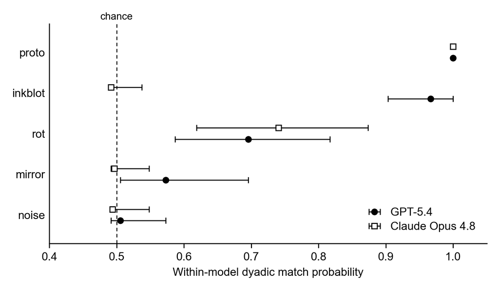

**Figure 1.** Within-model dyadic match probability by stimulus. Filled circles GPT-5.4, open squares Claude Opus 4.8. Bars are 95% bootstrap CIs (5,000 resamples). Dashed line marks chance.

### Three distinct mechanisms, not one

Requiring a sentence of reasoning before the choice made the failure modes legible, and they turned out to be different in kind.

1. **Genuine form coordination** — `proto` (both models 1.000) and `rot` (0.695 / 0.741). On `rot` the chosen side flips with the layout, which is the signature of tracking the shape rather than the position.
2. **Honest fallback** — Claude on `noise`, which states the position openly: “These both appear to be random noise with no clear form, so I’ll default to a simple tiebreaker.” There is no form signal to find; the model says so and picks a side deliberately. The measured 0.494 is the correct answer, not an artifact.
3. **Confabulated side default** — Claude on `inkblot`, answering `RIGHT` on 60 of 60 trials while giving a *form* justification each time, accurately describing whichever shape occupied the right slot: [layout BA] “The symmetric, star-like shape with balanced points is a more natural Schelling focal point than the irregular blob.”  
   [layout AB] “The right shape has two distinctive tall pointed spikes at the top, making it the more memorable, easily-agreed-upon form.” Different features cited depending on what sits on the right, and whichever it is gets called the focal point. The choice tracks position; the justification is fitted to it afterward. Identity lands at exactly 30/30.

### Why `mirror` fails where `rot` succeeds

This is a property of the stimuli, not of the models. `rot` is a blob rotated 90°, so one option is upright and one is sideways — a position-independent asymmetry that *both instances share a prior about*. `mirror` is a blob reflected across the vertical axis: reflection preserves area, complexity and lobe count, leaving only handedness, and handedness is exactly the dimension with no shared prior to break the tie. A rule can be stated, but there is no reason to prefer one sign of it, so rule-selection is itself a coin flip. Claude generated two incompatible chirality rules minutes apart:

“…coordinate on the shape with its lower point angling toward the **right**.”  
“…pick the one whose narrow point tucks toward the **bottom-left**.”

**The modal share is the misleading statistic on `mirror`, not the match rate.** GPT’s apparent “70% preference for blob-mirror” comes almost entirely from the BA layout, where blob-mirror sits on the left: it was chosen 29/30 there but only 13/30 when the same shape sat on the right. The match rate is unaffected — under a balanced counterbalance a side bias can only push it toward chance, never above it — so 0.573 remains an honest, conservative estimate.

## 4. Step 1b — 30-pair screen

1,800 calls (30 pairs × 2 models × 30), 862 s, zero unparseable responses, zero API errors. Two families were built:

- **16 single-cue pairs** vary one property with everything else matched — symmetry, complexity, regularity, curvature, convexity, elongation, size, tilt, closure, hole, numerosity, density, alignment, line orientation, contrast, semantic orientation.
- **14 competing-cue pairs** put two cues in opposition (small-symmetric vs large-asymmetric, spiky-small vs smooth-large, and so on), on the hypothesis that a model weighting one cue would diverge from a model weighting the other.

**The competing-cue hypothesis was wrong.** 18 of 30 pairs sat at a perfect 1.000/1.000 ceiling, including 9 of the 14 competing-cue pairs: the models resolve cue conflicts *identically* (size appears to dominate). Five of the eight dissociations came from single-cue pairs. Building conflict into a stimulus did not create disagreement, it created a harder problem that both models solved the same way.

### A selection criterion that had to be changed

The pre-specified criteria were: (1) P(left) between 0.35 and 0.65 for *both* models, (2) |Δ| > 0.15 in match probability, (3) form-based choosing. Applied as written, only two pairs passed, both in the same direction — **no crossover**.

The reason is mechanical, and it is the Step 1 finding resurfacing: a model with no form rule side-defaults rather than answering randomly, so a large |Δ| almost guarantees that the *low* model has an extreme P(left). Screening on both models therefore rejects precisely the dissociations being sought. Applying the position criterion to the **concentrated model only** costs nothing: the two models are separate API calls in separate cells, so the low model’s side default cannot bias the high model’s estimate, and under a balanced counterbalance a side default reads as chance on identity — the correct answer for “no form preference”. With that correction, 8 pairs pass and crossovers appear in both directions.

| pair | family | GPT | P(left) | form cons. | Claude | P(left) | form cons. | Δ | 95% CI on Δ |
| --- | --- | --- | --- | --- | --- | --- | --- | --- | --- |
| `s_arrow` | single | 0.503 | 0.23 | 0.47 | 1.000 | 0.50 | 1.00 | -0.497 | [-0.517, -0.370] |
| `c_open_cplx` | compete | 0.595 | 0.30 | 0.60 | 0.871 | 0.43 | 0.87 | -0.276 | [-0.460, -0.044] |
| `s_convexity` | single | 0.669 | 0.30 | 0.60 | 0.933 | 0.47 | 0.93 | -0.264 | [-0.434, +0.000] |
| `s_density` | single | 1.000 | 0.50 | 1.00 | 0.814 | 0.53 | 0.93 | +0.186 | [+0.000, +0.331] |
| `c_star_circle` | compete | 0.761 | 0.50 | 1.00 | 0.492 | 0.07 | 0.13 | +0.269 | [+0.074, +0.448] |
| `c_elong_sym` | compete | 0.814 | 0.47 | 0.93 | 0.485 | 0.03 | 0.07 | +0.329 | [+0.129, +0.497] |
| `s_contrast` | single | 1.000 | 0.50 | 1.00 | 0.630 | 0.60 | 0.80 | +0.370 | [+0.186, +0.497] |
| `s_complexity` | single | 1.000 | 0.50 | 1.00 | 0.485 | 0.10 | 0.20 | +0.515 | [+0.434, +0.517] |

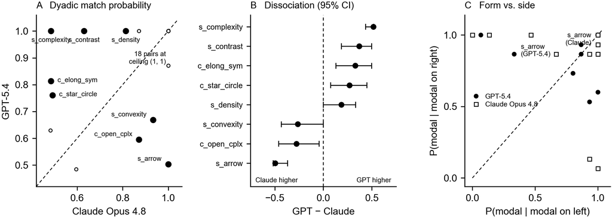

**Figure 2.** **(A)** Dyadic match probability, all 30 pairs; distance from the diagonal is the dissociation. Filled points passed all criteria. **(B)** Effect sizes with 95% bootstrap CIs for the selected pairs, both directions. **(C)** Conditional-position diagnostic: rate of choosing the modal identity when it sits on the left versus the right. Points on the diagonal indicate choosing by form; points off it indicate choosing by side. The two labelled `s_arrow` points show the mechanism — Claude at (1.0, 1.0), GPT far off the diagonal.

### The strongest result

`s_arrow` (up-arrow vs right-arrow) is the cleanest dissociation in the battery and the Claude > GPT anchor the earlier work lacked. Both models articulate the *same* rule — “up is canonical”. Claude applies it on 30 of 30 trials with P(left) exactly 0.50. GPT states it and then does not follow it:

“The upward-pointing arrow seems the more canonical and salient shape to coordinate on. **CHOICE: RIGHT**” (up was on the right — correct)  
“The right-pointing arrow feels like the more standard, salient arrow form. **CHOICE: RIGHT**” (rule switched to fit the side)

GPT answered `RIGHT` on 23 of 30 trials. This is the same confabulated side default Claude showed on `inkblot` in Step 1, with the models’ roles reversed.

## 5. Recommendation for the next experiment

| pair | direction | GPT | Claude | Δ | both models in position band |
| --- | --- | --- | --- | --- | --- |
| `s_arrow` | Claude > GPT | 0.503 | 1.000 | -0.497 | no |
| `s_convexity` | Claude > GPT | 0.669 | 0.933 | -0.264 | no |
| `s_contrast` | GPT > Claude | 1.000 | 0.630 | +0.370 | yes |
| `s_density` | GPT > Claude | 1.000 | 0.814 | +0.186 | yes |

Add `c_open_cplx` (Δ −0.276) for a third pair in the Claude direction, plus `s_size` or `s_symmetry` as a shared-focal positive control (both models 1.000) and Step 1’s `noise` as a floor control.

**Discard three of the eight that passed.** `s_complexity` despite the largest Δ: its 20-gon is perceptually a circle, so the pair measures prototypicality and duplicates `proto`. `c_elong_sym` and `c_star_circle`: Claude’s form consistency there is 0.07 and 0.13, meaning its identity choice is entirely positional — “Claude does not coordinate here” is not interpretable when Claude is not engaging with the stimulus at all.

**The two directions are not the same kind of effect.** In the GPT > Claude pairs, Claude is genuinely tracking form, just less consistently (form consistency 0.80 and 0.93) — a *graded difference in concentration*. In the Claude > GPT pairs, GPT is partly falling back to position (form consistency 0.47–0.60) — a *difference in kind*. Both support the claim “these models have different focal points”. Only `s_contrast` and `s_density` support the stronger claim “model X converges where model Y is genuinely indifferent”, and both are the same direction. If that distinction matters, more candidates are needed in the Claude > GPT direction, screened for GPT staying near P(left) = 0.5 while failing to concentrate. `s_arrow` suggests semantic and canonical-orientation cues as the place to look.

## 7. Files

All paths relative to `Name_game_experiment/`.

| file | contents |
| --- | --- |
| `step1_form_choice.py` | Step 1 runner — prompt, settings, counterbalance |
| `step1_form_analysis.py` | Step 1 statistics and Figure 1 |
| `step1_output/step1_form_calls_20260804_124918.csv` | 600 call-level rows with full reasoning traces |
| `step1_output/step1_deliverables_20260804_124918/` | packaged raw data, summary, comparison, run config |
| `make_screen_stimuli.py` | generates the 30-pair battery and manifest |
| `step1b_screen.py` | screen runner; imports the prompt from Step 1 |
| `step1b_screen_analysis.py` | selection criteria and diagnostics |
| `step1b_screen_figure.py` | Figure 2 |
| `step1_output/step1b_screen_calls_20260804_153626.csv` | 1,800 call-level rows |
| `step1_output/step1b_screen_selected_20260804_153626.csv` | per-pair criteria and crossover flags |

## Appendix — the 30-pair screening battery

Each panel shows the `_AB` layout: identity 1 left, identity 2 right. Position is counterbalanced across trials.

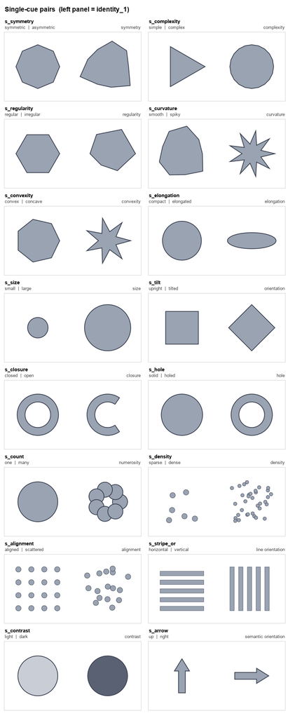

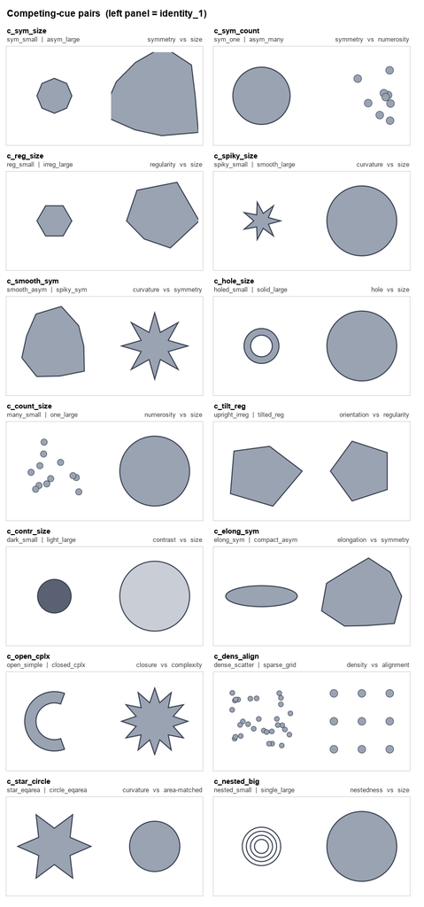